# Using hierarchical clustering to remove multicollinearity

## Cluster 21: revenue measures

```
Minimum absolute correlation: 0.87
```

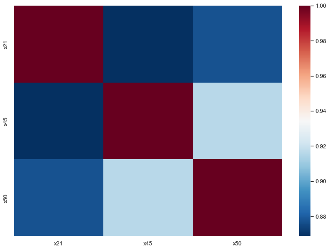

```python
plot_cluster_corr_matrix(corr, clustering, 21)
```

```python
compute_corr_with_target(df, clustering, 21)
```

```
x45   -0.09
x21   -0.07
x50    0.01
dtype: float64
```

```python
compute_skew(df, clustering, 21)
```

```
x21    43.77
x50     8.96
x45     2.34
dtype: float64
```

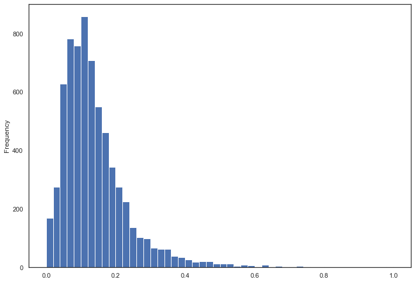

```python
plot_feature_hist(df, "x45")
```

```python
selected_features.append("x45")
```

## Cluster 1: net value per share

```
Minimum absolute correlation: 1.0
```

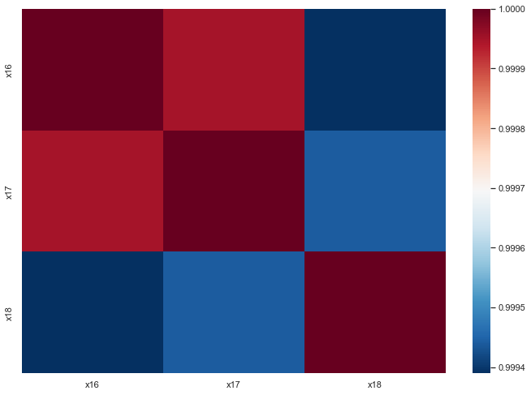

```python
plot_cluster_corr_matrix(corr, clustering, 1)
```

```python
compute_corr_with_target(df, clustering, 1)
```

```
x16   -0.21
x17   -0.21
x18   -0.20
dtype: float64
```

```python
compute_skew(df, clustering, 1)
```

```
x16    4.56
x17    4.52
x18    4.51
dtype: float64
```

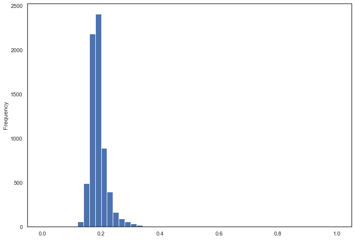

```python
plot_feature_hist(df, "x16")
```

```python
selected_features.append("x16")
```

## Cluster 14: payment of short-term debts given to customers (receivables)

```
Minimum absolute correlation: 0.96
```

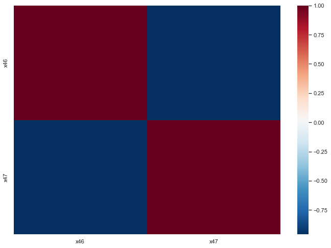

```python
plot_cluster_corr_matrix(corr, clustering, 14)
```

```python
compute_corr_with_target(df, clustering, 14)
```

```
x47    0.03
x46   -0.02
dtype: float64
```

```python
compute_skew(df, clustering, 14)
```

```
x47    30.58
x46    25.85
dtype: float64
```

The selected feature here is x47: average collection days.

```python
selected_features.append("x47")
```

## Cluster 24: inflation-related measures

```
Minimum absolute correlation: 0.5
```

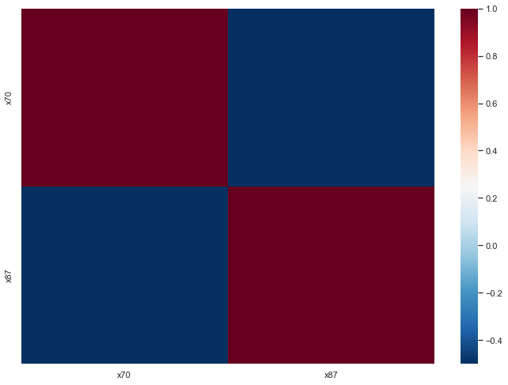

```python
plot_cluster_corr_matrix(corr, clustering, 24)
```

```python
compute_corr_with_target(df, clustering, 24)
```

```
x70    0.08
x87    0.06
dtype: float64
```

```python
compute_skew(df, clustering, 24)
```

```
x87    21.76
x70     9.48
dtype: float64
```

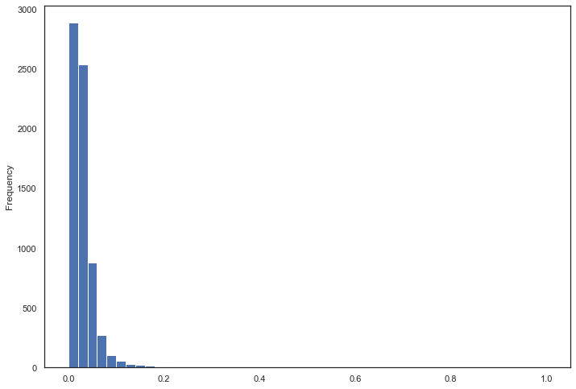

```python
plot_feature_hist(df, "x70")
```

```python
selected_features.append("x70")
```

## Cluster 27: cash stock measures

```
Minimum absolute correlation: 0.86
```

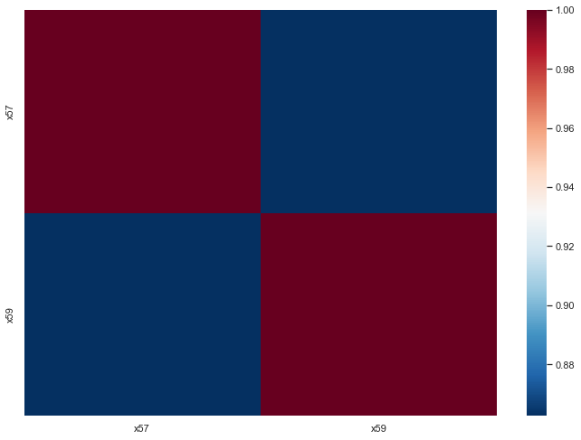

```python
plot_cluster_corr_matrix(corr, clustering, 27)
```

```python
compute_corr_with_target(df, clustering, 27)
```

```
x57   -0.15
x59   -0.15
dtype: float64
```

```python
compute_skew(df, clustering, 27)
```

```
x59    14.86
x57     2.23
dtype: float64
```

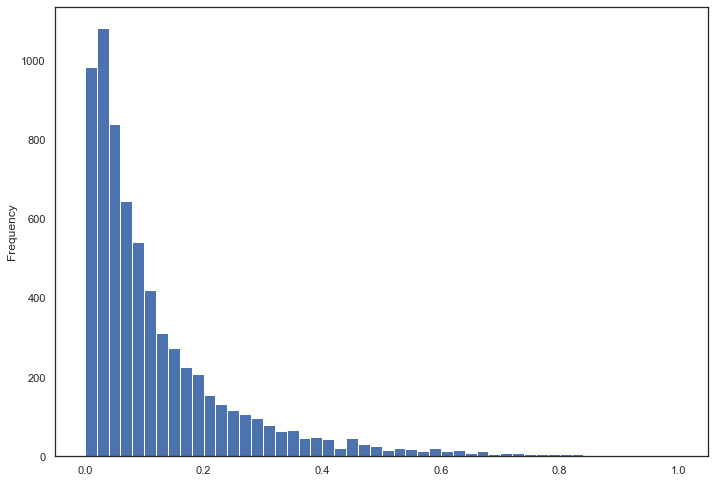

```python
plot_feature_hist(df, "x57")
```

```python
selected_features.append("x57")
```

## Completing selected features list with features of single-feature clusters

```python
for cluster_id in [k for k, v in clustering.items() if len(v) == 1]:
    selected_features.append(clustering[cluster_id][0])
selected_features = list(set(selected_features))
selected_features
```

```
['x57',
 'x11',
 'x30',
 'x84',
 'x45',
 'x54',
 'x61',
 'x72',
 'x93',
 'x70',
 'x14',
 'x88',
 'x47',
 'x62',
 'x09',
 'x80',
 'x48',
 'x04',
 'x79',
 'x71',
 'x39',
 'x26',
 'x29',
 'x41',
 'x51',
 'x15',
 'x63',
 'x19',
 'x37',
 'x16',
 'x49',
 'x74',
 'x12']
```

```python
len(selected_features)
```

```
33
```

```python
len(clustering)
```

```
33
```

## Analysing selected features

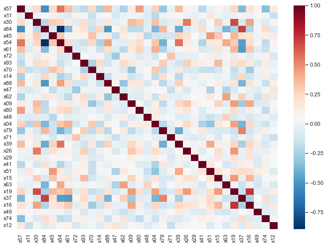

```python
_ = sns.heatmap(corr.loc[selected_features, selected_features], cmap="RdBu_r")
```

```python
np.fill_diagonal(corr.loc[selected_features, selected_features].values, np.nan)
```

```python
corr2 = corr.loc[selected_features, selected_features].copy()
np.fill_diagonal(corr2.values, np.nan)
corr2
```

|  | x57 | x11 | x30 | x84 | x45 | x54 | x61 | x72 | x93 | x70 | ... | x41 | x51 | x15 | x63 | x19 | x37 | x16 | x49 | x74 | x12 |
| --- | --- | --- | --- | --- | --- | --- | --- | --- | --- | --- | --- | --- | --- | --- | --- | --- | --- | --- | --- | --- | --- |
| x57 | NaN | -0.028920 | 0.236476 | -0.527554 | 0.239994 | 0.558081 | 0.339001 | -0.141463 | -0.195838 | 0.244762 | ... | -0.204225 | -0.009303 | 0.068489 | -0.018052 | 0.255201 | -0.365217 | 0.190582 | 0.082637 | -0.346282 | 0.137527 |
| x11 | -0.028920 | NaN | -0.000555 | 0.047102 | 0.108116 | -0.020399 | -0.064163 | 0.100989 | 0.022964 | -0.159064 | ... | 0.038594 | 0.170050 | 0.001478 | -0.033560 | -0.004836 | 0.073603 | -0.000414 | 0.055513 | 0.021762 | -0.160235 |
| x30 | 0.236476 | -0.000555 | NaN | -0.198293 | 0.286649 | 0.258352 | 0.118116 | -0.047432 | 0.217674 | -0.115353 | ... | -0.105553 | 0.052896 | 0.285770 | 0.003537 | 0.669339 | -0.097990 | 0.436912 | 0.013981 | -0.071779 | 0.084147 |
| x84 | -0.527554 | 0.047102 | -0.198293 | NaN | -0.082807 | -0.890891 | -0.352150 | 0.111914 | 0.188930 | -0.145241 | ... | 0.202762 | 0.023454 | -0.086670 | -0.380458 | -0.243053 | 0.702851 | -0.232250 | 0.026822 | 0.229637 | -0.073221 |
| x45 | 0.239994 | 0.108116 | 0.286649 | -0.082807 | NaN | 0.306532 | 0.030131 | 0.089430 | 0.100563 | 0.324503 | ... | -0.022449 | 0.462180 | 0.307309 | 0.047568 | 0.362441 | 0.194795 | 0.169078 | 0.014740 | 0.122081 | 0.128449 |
| x54 | 0.558081 | -0.020399 | 0.258352 | -0.890891 | 0.306532 | NaN | 0.236736 | -0.094916 | -0.159478 | 0.239930 | ... | -0.231538 | 0.147576 | 0.131665 | 0.415904 | 0.292743 | -0.469579 | 0.211526 | 0.019473 | -0.187008 | 0.038032 |
| x61 | 0.339001 | -0.064163 | 0.118116 | -0.352150 | 0.030131 | 0.236736 | NaN | -0.081718 | -0.053175 | 0.018204 | ... | -0.078679 | -0.060845 | 0.176542 | -0.003271 | 0.376967 | -0.482163 | 0.312700 | -0.051086 | -0.159220 | 0.089349 |
| x72 | -0.141463 | 0.100989 | -0.047432 | 0.111914 | 0.089430 | -0.094916 | -0.081718 | NaN | 0.046167 | 0.004450 | ... | 0.027466 | 0.115299 | -0.022461 | 0.081243 | -0.046590 | 0.097014 | -0.055332 | 0.018743 | 0.105545 | -0.102631 |
| x93 | -0.195838 | 0.022964 | 0.217674 | 0.188930 | 0.100563 | -0.159478 | -0.053175 | 0.046167 | NaN | -0.241848 | ... | 0.117755 | 0.092629 | 0.355067 | 0.005915 | 0.200742 | 0.234860 | 0.129779 | -0.107373 | 0.125121 | -0.015318 |
| x70 | 0.244762 | -0.159064 | -0.115353 | -0.145241 | 0.324503 | 0.239930 | 0.018204 | 0.004450 | -0.241848 | NaN | ... | -0.160889 | -0.161187 | -0.112649 | 0.027057 | -0.168692 | -0.036129 | -0.284005 | 0.003304 | 0.003585 | 0.029218 |
| x14 | -0.257177 | 0.029488 | -0.027037 | 0.256886 | -0.004563 | -0.233949 | -0.157086 | 0.085042 | 0.241472 | -0.041663 | ... | 0.090753 | 0.023726 | -0.023781 | 0.014714 | -0.133693 | 0.252341 | -0.139147 | -0.017347 | 0.123532 | -0.059803 |
| x88 | 0.360105 | 0.034540 | 0.166860 | -0.487615 | 0.122364 | 0.444325 | 0.202178 | -0.122188 | -0.123774 | -0.001052 | ... | -0.020531 | 0.036142 | 0.120646 | -0.020870 | 0.182779 | -0.383376 | 0.186118 | 0.020815 | -0.156293 | 0.107617 |
| x47 | -0.058346 | -0.097047 | -0.034095 | 0.026554 | -0.179499 | -0.031109 | -0.073334 | -0.290903 | 0.004828 | 0.002270 | ... | 0.073454 | -0.236394 | 0.029260 | -0.232702 | -0.089467 | 0.037267 | -0.025178 | -0.054095 | 0.024339 | 0.184124 |
| x62 | -0.238074 | 0.008081 | 0.001866 | 0.161555 | 0.127650 | -0.051081 | -0.200436 | 0.103954 | 0.221437 | -0.091455 | ... | 0.076600 | 0.145186 | 0.038012 | 0.445184 | -0.005889 | 0.277311 | -0.012237 | -0.150909 | 0.186614 | -0.039475 |
| x09 | 0.131724 | 0.005914 | 0.353257 | -0.197447 | 0.038394 | 0.130260 | 0.151499 | -0.003478 | 0.158227 | -0.307309 | ... | 0.058648 | 0.049739 | 0.271422 | -0.050396 | 0.456497 | -0.281964 | 0.420708 | -0.074014 | -0.061721 | 0.065632 |
| x80 | 0.451583 | 0.006837 | 0.305638 | -0.183352 | 0.130130 | 0.225340 | 0.267999 | -0.065234 | 0.002682 | -0.002663 | ... | -0.064080 | 0.032534 | 0.070192 | 0.002076 | 0.216851 | -0.064755 | 0.126306 | 0.023472 | -0.187303 | 0.016226 |
| x48 | -0.050595 | -0.073361 | -0.058575 | -0.042902 | -0.204783 | 0.037555 | -0.042338 | -0.014216 | -0.015044 | 0.052514 | ... | -0.069515 | -0.157074 | -0.078778 | 0.272844 | -0.104788 | -0.031849 | -0.107254 | -0.032865 | 0.007586 | -0.071256 |
| x04 | 0.268952 | -0.211107 | 0.331436 | -0.371681 | -0.132583 | 0.320290 | 0.388271 | -0.126005 | 0.015887 | 0.300508 | ... | -0.233684 | -0.321499 | 0.171349 | 0.069809 | 0.443520 | -0.385797 | 0.250902 | -0.077196 | -0.140362 | 0.006239 |
| x79 | -0.307156 | 0.009816 | -0.079477 | 0.363128 | -0.144420 | -0.391950 | -0.238481 | 0.047307 | 0.285810 | -0.179062 | ... | 0.152873 | -0.071294 | -0.087108 | -0.086052 | -0.146517 | 0.526506 | -0.126485 | -0.024086 | 0.110631 | 0.042703 |
| x71 | -0.018944 | 0.096275 | -0.041568 | -0.001897 | -0.114215 | 0.023309 | -0.045932 | 0.327810 | -0.040663 | -0.027362 | ... | -0.035082 | 0.061942 | -0.083518 | 0.043353 | -0.090098 | -0.002957 | -0.069134 | 0.074441 | -0.054189 | -0.161572 |
| x39 | 0.346004 | 0.053717 | 0.165889 | -0.425036 | 0.262520 | 0.567792 | 0.040865 | -0.040865 | -0.130611 | 0.143703 | ... | 0.100546 | 0.414805 | 0.113371 | 0.112328 | 0.251265 | -0.258911 | 0.253564 | 0.132250 | -0.087419 | 0.002851 |
| x26 | 0.087620 | 0.000156 | 0.548128 | -0.083244 | 0.194789 | 0.123648 | 0.097784 | -0.021492 | 0.279796 | -0.107846 | ... | -0.063317 | 0.050255 | 0.214556 | 0.005729 | 0.465935 | -0.018304 | 0.193099 | -0.011464 | -0.015521 | 0.039334 |
| x29 | 0.006228 | -0.028776 | 0.152464 | -0.022042 | 0.052544 | 0.019812 | 0.069332 | -0.039347 | 0.132757 | -0.081502 | ... | 0.022889 | 0.007555 | 0.160788 | -0.008213 | 0.207295 | -0.025147 | 0.158793 | -0.056617 | 0.034275 | 0.047736 |
| x41 | -0.204225 | 0.038594 | -0.105553 | 0.202762 | -0.022449 | -0.231538 | -0.078679 | 0.027466 | 0.117755 | -0.160889 | ... | NaN | 0.175668 | 0.050437 | -0.115303 | -0.036860 | 0.123320 | 0.097800 | -0.071765 | 0.112032 | 0.048477 |
| x51 | -0.009303 | 0.170050 | 0.052896 | 0.023454 | 0.462180 | 0.147576 | -0.060845 | 0.115299 | 0.092629 | -0.161187 | ... | 0.175668 | NaN | 0.183601 | 0.081342 | 0.206149 | 0.233888 | 0.210061 | 0.121147 | 0.088260 | -0.072957 |
| x15 | 0.068489 | 0.001478 | 0.285770 | -0.086670 | 0.307309 | 0.131665 | 0.176542 | -0.022461 | 0.355067 | -0.112649 | ... | 0.050437 | 0.183601 | NaN | -0.025786 | 0.467998 | -0.023043 | 0.366498 | -0.089368 | 0.040869 | 0.033465 |
| x63 | -0.018052 | -0.033560 | 0.003537 | -0.380458 | 0.047568 | 0.415904 | -0.003271 | 0.081243 | 0.005915 | 0.027057 | ... | -0.115303 | 0.081342 | -0.025786 | NaN | 0.008814 | -0.149043 | -0.016624 | -0.129568 | 0.015497 | -0.097139 |
| x19 | 0.255201 | -0.004836 | 0.669339 | -0.243053 | 0.362441 | 0.292743 | 0.376967 | -0.046590 | 0.200742 | -0.168692 | ... | -0.036860 | 0.206149 | 0.467998 | 0.008814 | NaN | -0.168155 | 0.736787 | -0.028941 | -0.053640 | 0.126084 |
| x37 | -0.365217 | 0.073603 | -0.097990 | 0.702851 | 0.194795 | -0.469579 | -0.482163 | 0.097014 | 0.234860 | -0.036129 | ... | 0.123320 | 0.233888 | -0.023043 | -0.149043 | -0.168155 | NaN | -0.245986 | 0.050282 | 0.220822 | -0.077267 |
| x16 | 0.190582 | -0.000414 | 0.436912 | -0.232250 | 0.169078 | 0.211526 | 0.312700 | -0.055332 | 0.129779 | -0.284005 | ... | 0.097800 | 0.210061 | 0.366498 | -0.016624 | 0.736787 | -0.245986 | NaN | -0.000944 | -0.065016 | 0.150547 |
| x49 | 0.082637 | 0.055513 | 0.013981 | 0.026822 | 0.014740 | 0.019473 | -0.051086 | 0.018743 | -0.107373 | 0.003304 | ... | -0.071765 | 0.121147 | -0.089368 | -0.129568 | -0.028941 | 0.050282 | -0.000944 | NaN | -0.049826 | -0.036796 |
| x74 | -0.346282 | 0.021762 | -0.071779 | 0.229637 | 0.122081 | -0.187008 | -0.159220 | 0.105545 | 0.125121 | 0.003585 | ... | 0.112032 | 0.088260 | 0.040869 | 0.015497 | -0.053640 | 0.220822 | -0.065016 | -0.049826 | NaN | 0.022558 |
| x12 | 0.137527 | -0.160235 | 0.084147 | -0.073221 | 0.128449 | 0.038032 | 0.089349 | -0.102631 | -0.015318 | 0.029218 | ... | 0.048477 | -0.072957 | 0.033465 | -0.097139 | 0.126084 | -0.077267 | 0.150547 | -0.036796 | 0.022558 | NaN |

33 rows × 33 columns

```python
corr2.abs().max().max()
```

```
0.8908906644825952
```

```python
corr2.abs().max().sort_values(ascending=False)
```

```
x84    0.890891
x54    0.890891
x16    0.736787
x19    0.736787
x37    0.702851
x30    0.669339
x39    0.567792
x57    0.558081
x26    0.548128
x79    0.526506
x88    0.487615
x61    0.482163
x15    0.467998
x45    0.462180
x51    0.462180
x09    0.456497
x80    0.451583
x63    0.445184
x62    0.445184
x04    0.443520
x93    0.355067
x74    0.346282
x71    0.327810
x72    0.327810
x70    0.324503
x47    0.290903
x48    0.272844
x14    0.257177
x41    0.233684
x11    0.211107
x29    0.207295
x12    0.184124
x49    0.150909
dtype: float64
```

Features in different categories are highly correlated, which makes sense because different things go together in practice (like liabilities and working capital).

## Second round of Ward's clustering

Now that we narrowed the dimension down to 33 (of the original 96), it is time to further remove correlated features. Now, lets focus only on features if maximum absolute correlation above 40%. Every feature with maximum absolute correlation below 40% will be automatically selected.

```python
CORR_CUTOFF = 0.4
temp = corr2.abs().max()
features = {x for x in temp[temp < CORR_CUTOFF].index}
features
```

```
{'x11',
 'x12',
 'x14',
 'x29',
 'x41',
 'x47',
 'x48',
 'x49',
 'x70',
 'x71',
 'x72',
 'x74',
 'x93'}
```

```python
corr3 = df[[x for x in selected_features if x not in features and x != "x00"]].corr("spearman")
corr3.shape
```

```
(20, 20)
```

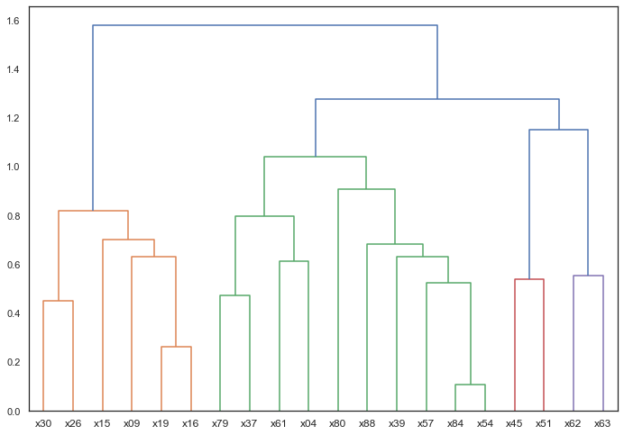

```python
distance_matrix2 = 1 - corr3.abs()
_ = hierarchy.dendrogram(
    hierarchy.ward(distance.squareform(distance_matrix2)),
    labels=corr3.columns.to_list()
)
```

```python
DISTANCE_THRESHOLD = 1
clustering = cluster_features_ward(distance_matrix2, DISTANCE_THRESHOLD)
len(clustering)
```

```
5
```

```python
pd.Series({k: len(v) for k, v in clustering.items()}, name="features").sort_values(ascending=False)
```

```
3    6
1    6
2    4
4    2
5    2
Name: features, dtype: int64
```

## Cluster 3

```python
def corr_table(df, cluster_map, cluster_id):
    return df[cluster_map[cluster_id]].corr("spearman").style.background_gradient().format(precision=2)
```

```python
corr_table(df, clustering, 3)
```

|  | x57 | x84 | x54 | x88 | x80 | x39 |
| --- | --- | --- | --- | --- | --- | --- |
| x57 | 1.00 | -0.53 | 0.56 | 0.36 | 0.45 | 0.35 |
| x84 | -0.53 | 1.00 | -0.89 | -0.49 | -0.18 | -0.43 |
| x54 | 0.56 | -0.89 | 1.00 | 0.44 | 0.23 | 0.57 |
| x88 | 0.36 | -0.49 | 0.44 | 1.00 | 0.16 | 0.27 |
| x80 | 0.45 | -0.18 | 0.23 | 0.16 | 1.00 | 0.12 |
| x39 | 0.35 | -0.43 | 0.57 | 0.27 | 0.12 | 1.00 |

```python
features.add("x39")
features.add("x88")
```

```python
df[["x57", "x80"]].corrwith(df["x00"], method="spearman")
```

```
x57   -0.150828
x80   -0.088504
dtype: float64
```

```python
features.add("x57")
```

## Cluster 1

```python
corr_table(df, clustering, 1)
```

|  | x30 | x09 | x26 | x15 | x19 | x16 |
| --- | --- | --- | --- | --- | --- | --- |
| x30 | 1.00 | 0.35 | 0.55 | 0.29 | 0.67 | 0.44 |
| x09 | 0.35 | 1.00 | 0.31 | 0.27 | 0.46 | 0.42 |
| x26 | 0.55 | 0.31 | 1.00 | 0.21 | 0.47 | 0.19 |
| x15 | 0.29 | 0.27 | 0.21 | 1.00 | 0.47 | 0.37 |
| x19 | 0.67 | 0.46 | 0.47 | 0.47 | 1.00 | 0.74 |
| x16 | 0.44 | 0.42 | 0.19 | 0.37 | 0.74 | 1.00 |

```python
compute_corr_with_target(df, clustering, 1)
```

```
x19   -0.24
x16   -0.21
x30   -0.20
x09   -0.20
x15   -0.16
x26   -0.12
dtype: float64
```

```python
compute_skew(df, clustering, 1)
```

```
x30    80.29
x09    39.64
x26   -25.58
x19     5.14
x16     4.56
x15     1.90
dtype: float64
```

```python
features.add("x19")
```

## Cluster 2

```python
corr_table(df, clustering, 2)
```

|  | x61 | x04 | x79 | x37 |
| --- | --- | --- | --- | --- |
| x61 | 1.00 | 0.39 | -0.24 | -0.48 |
| x04 | 0.39 | 1.00 | -0.20 | -0.39 |
| x79 | -0.24 | -0.20 | 1.00 | 0.53 |
| x37 | -0.48 | -0.39 | 0.53 | 1.00 |

```python
features.add("x04")
```

```python
df[["x37", "x61", "x79"]].corrwith(df["x00"], method="spearman")
```

```
x37    0.217237
x61   -0.145005
x79    0.117302
dtype: float64
```

```python
df[["x37", "x61", "x79"]].skew()
```

```
x37     0.980796
x61     3.777297
x79    33.789940
dtype: float64
```

```python
features.add("x37")
```

## Cluster 4

```python
corr_table(df, clustering, 4)
```

|  | x45 | x51 |
| --- | --- | --- |
| x45 | 1.00 | 0.46 |
| x51 | 0.46 | 1.00 |

```python
compute_corr_with_target(df, clustering, 4)
```

```
x45   -0.09
x51    0.02
dtype: float64
```

```python
features.add("x45")
```

## Cluster 5

```python
corr_table(df, clustering, 5)
```

|  | x62 | x63 |
| --- | --- | --- |
| x62 | 1.00 | 0.45 |
| x63 | 0.45 | 1.00 |

```python
compute_corr_with_target(df, clustering, 5)
```

```
x62   -0.06
x63   -0.06
dtype: float64
```

```python
compute_skew(df, clustering, 5)
```

```
x62    45.33
x63    11.97
dtype: float64
```

```python
features.add("x63")
```

## Final correlation matrix

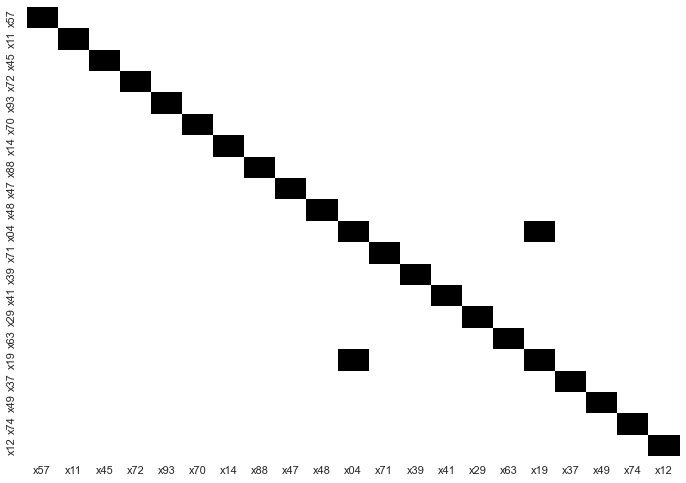

```python
features = list(features)
corr_final = df[features].corr("spearman")
_ = sns.heatmap(corr_final.gt(0.4), cmap="Greys", cbar=False)
```

```python
corr_final.at["x04", "x19"]
```

```
0.4435200065239463
```

```python
df[["x04", "x19"]].corrwith(df["x00"], method="spearman")
```

```
x04   -0.147648
x19   -0.238209
dtype: float64
```

```python
features.remove("x04")
print(len(features))
features
```

```
20
```

```
['x57',
 'x11',
 'x45',
 'x72',
 'x93',
 'x70',
 'x14',
 'x88',
 'x47',
 'x48',
 'x71',
 'x39',
 'x41',
 'x29',
 'x63',
 'x19',
 'x37',
 'x49',
 'x74',
 'x12']
```

```python
temp = df[features].corr(method="spearman")
np.fill_diagonal(temp.values, np.nan)
assert temp.abs().max().max() <= 0.4
```

```python
json.dump(sorted(features), open("../data/features.json", "w"), indent=4)
```